# Machine Learning Project

Yuxuan Ji

7/26/2020

First of all, load the traing dataset and testing dataset. On the purpose of making data processing more straightforward, consider empty string("") as `NA`.

```r
library(tidyverse)
library(ggplot2)
library(caret)
library(randomForest)
library(rattle)

training <- read.csv("pml-training.csv", na.strings = c("", NA))
testing <- read.csv("pml-testing.csv", na.strings = c("", NA))
```

### Variable Selection

By looking at the summary of the `training` dataset, we could know that there are 160 variables and 19622 observations in the dataset. Meanwhile, by looking at the dataset itself, there are a lot of variables that have value `NA` and `""` which are not very useful when training modela. Therefore, we should eliminate variables that have `NA` and `""`.

```r
# Delete columns with all missing values
training <- training[,colSums(is.na(training)) == 0]
testing <- testing[,colSums(is.na(testing)) == 0]
```

After eliminating variables that have `NA`s, there are 60 variables left among which there are a few irrelavant variables such as `X`, `user_name`, `raw_timestamp_part_1`. Therefore, we delete the first 7 columns which are index variable, user_name and time-related variables respectively.

```r
training <- training[, -c(1:7)]
testing <- testing[, -c(1:7)]
```

Based on the description on the website, there are 5 different `classe` which are A(exactly according to the specification, B(throwing the elbows to the front), C(lifting the dumbbell only halfway), D(lowering the dumbbell only halfway) and E(throwing the hips to the front) respectively. Thus, we have the following plot as a descriptive analysism of the variable that we want to perdict.

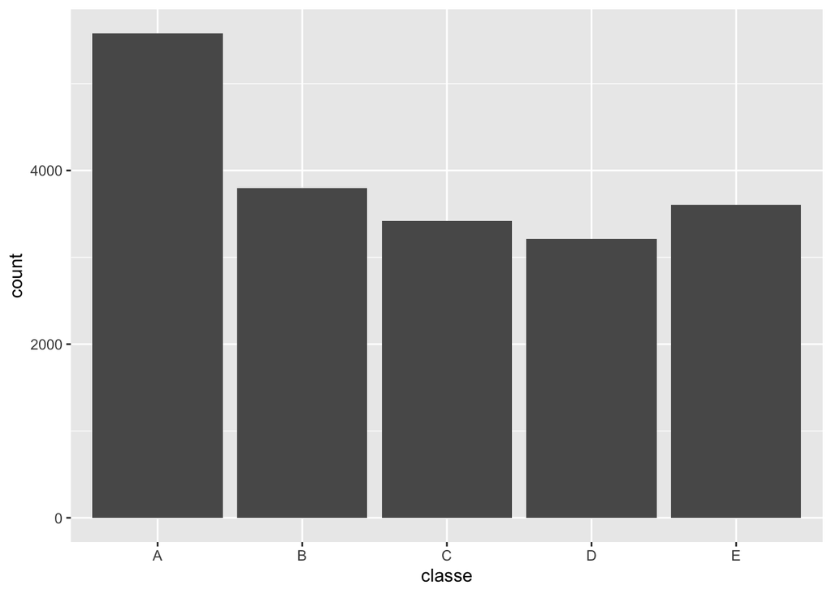

```r
training %>% ggplot(aes(x=classe)) + geom_bar()
```

According to the histogram above, we should expect class A as the most frequent label while the other 4 classes are relatively the same.

### Cross Validation

In order to compare the performance of different models, we split the training dataset into two subsets - `subTraining` and `subTesting`. To be more specific, the former container 75% of the training dataset while the latter contains 25%. Therefore, the original `testing` dataset should be treated as validation dataset by which we performed cross-validation.

```r
set.seed(723)
inTrain <- createDataPartition( y = training$classe, p = 0.75, list = FALSE)

subTraining <- training[inTrain,]
subTesting <- training[-inTrain,]
```

### Model Building

#### Model1: Decision Tree

```r
# train the model
model1 <- train(classe~., method = "rpart", data= subTraining)
# summary of the final model
model1$finalModel
```

```
## n= 14718
##
## node), split, n, loss, yval, (yprob)
##       * denotes terminal node
##
##  1) root 14718 10533 A (0.28 0.19 0.17 0.16 0.18)
##    2) roll_belt< 130.5 13486  9310 A (0.31 0.21 0.19 0.18 0.11)
##      4) pitch_forearm< -33.95 1202     7 A (0.99 0.0058 0 0 0) *
##      5) pitch_forearm>=-33.95 12284  9303 A (0.24 0.23 0.21 0.2 0.12)
##       10) magnet_dumbbell_y< 439.5 10363  7452 A (0.28 0.18 0.24 0.19 0.11)
##         20) roll_forearm< 122.5 6431  3820 A (0.41 0.18 0.18 0.17 0.06) *
##         21) roll_forearm>=122.5 3932  2616 C (0.076 0.18 0.33 0.23 0.18) *
##       11) magnet_dumbbell_y>=439.5 1921   953 B (0.036 0.5 0.041 0.22 0.2) *
##    3) roll_belt>=130.5 1232     9 E (0.0073 0 0 0 0.99) *
```

[figure not shown]

```r
fancyRpartPlot(model1$finalModel)
```

```r
# predicting on subTesting dataset
predict1 <- predict(model1, newdata = subTesting)
# prediction accuracy
confusionMatrix(predict1, factor(subTesting$classe))
```

```
## Confusion Matrix and Statistics
##
##           Reference
## Prediction    A    B    C    D    E
##          A 1269  377  414  353  140
##          B   11  318   29  142  108
##          C  110  254  412  309  245
##          D    0    0    0    0    0
##          E    5    0    0    0  408
##
## Overall Statistics
##
##                Accuracy : 0.4908
##                  95% CI : (0.4767, 0.5049)
##     No Information Rate : 0.2845
##     P-Value [Acc > NIR] : < 2.2e-16
##
##                   Kappa : 0.3346
##
##  Mcnemar's Test P-Value : NA
##
## Statistics by Class:
##
##                      Class: A Class: B Class: C Class: D Class: E
## Sensitivity            0.9097  0.33509  0.48187   0.0000  0.45283
## Specificity            0.6341  0.92668  0.77328   1.0000  0.99875
## Pos Pred Value         0.4971  0.52303  0.30977      NaN  0.98789
## Neg Pred Value         0.9464  0.85312  0.87605   0.8361  0.89022
## Prevalence             0.2845  0.19352  0.17435   0.1639  0.18373
## Detection Rate         0.2588  0.06485  0.08401   0.0000  0.08320
## Detection Prevalence   0.5206  0.12398  0.27121   0.0000  0.08422
## Balanced Accuracy      0.7719  0.63088  0.62757   0.5000  0.72579
```

#### Model2: Random Forest

```r
# train the model
model2 <- randomForest(factor(classe) ~., data = subTraining)

# predicting on subTesting dataset
predict2 <- predict(model2, newdata = subTesting)
# prediction accuracy
confusionMatrix(predict2, factor(subTesting$classe))
```

```
## Confusion Matrix and Statistics
##
##           Reference
## Prediction    A    B    C    D    E
##          A 1395    5    0    0    0
##          B    0  940    3    0    0
##          C    0    4  851    8    1
##          D    0    0    1  793    1
##          E    0    0    0    3  899
##
## Overall Statistics
##
##                Accuracy : 0.9947
##                  95% CI : (0.9922, 0.9965)
##     No Information Rate : 0.2845
##     P-Value [Acc > NIR] : < 2.2e-16
##
##                   Kappa : 0.9933
##
##  Mcnemar's Test P-Value : NA
##
## Statistics by Class:
##
##                      Class: A Class: B Class: C Class: D Class: E
## Sensitivity            1.0000   0.9905   0.9953   0.9863   0.9978
## Specificity            0.9986   0.9992   0.9968   0.9995   0.9993
## Pos Pred Value         0.9964   0.9968   0.9850   0.9975   0.9967
## Neg Pred Value         1.0000   0.9977   0.9990   0.9973   0.9995
## Prevalence             0.2845   0.1935   0.1743   0.1639   0.1837
## Detection Rate         0.2845   0.1917   0.1735   0.1617   0.1833
## Detection Prevalence   0.2855   0.1923   0.1762   0.1621   0.1839
## Balanced Accuracy      0.9993   0.9949   0.9961   0.9929   0.9985
```

#### Model3: Boosting

```r
# train the model
model3 <- train(classe ~., data = subTraining, method = "gbm", verbose = FALSE)

# predicting on subTesting dataset
predict3 <- predict(model3, newdata = subTesting)
# prediction accuracy
confusionMatrix(predict3, factor(subTesting$classe))
```

```
## Confusion Matrix and Statistics
##
##           Reference
## Prediction    A    B    C    D    E
##          A 1375   27    0    0    5
##          B   11  889   32    0    7
##          C    6   33  810   25    9
##          D    2    0    9  770    7
##          E    1    0    4    9  873
##
## Overall Statistics
##
##                Accuracy : 0.9619
##                  95% CI : (0.9561, 0.9671)
##     No Information Rate : 0.2845
##     P-Value [Acc > NIR] : < 2.2e-16
##
##                   Kappa : 0.9518
##
##  Mcnemar's Test P-Value : NA
##
## Statistics by Class:
##
##                      Class: A Class: B Class: C Class: D Class: E
## Sensitivity            0.9857   0.9368   0.9474   0.9577   0.9689
## Specificity            0.9909   0.9874   0.9820   0.9956   0.9965
## Pos Pred Value         0.9773   0.9468   0.9173   0.9772   0.9842
## Neg Pred Value         0.9943   0.9849   0.9888   0.9917   0.9930
## Prevalence             0.2845   0.1935   0.1743   0.1639   0.1837
## Detection Rate         0.2804   0.1813   0.1652   0.1570   0.1780
## Detection Prevalence   0.2869   0.1915   0.1801   0.1607   0.1809
## Balanced Accuracy      0.9883   0.9621   0.9647   0.9767   0.9827
```

### Conclusion

##### Estimate out-of-sample error

Because we have chosen `predicting with random forest` as our model, the out of sample erro would be about 0.005.

### Prediction of the Testing dataset

```r
predict(model2, newdata = testing)
```

```
##  1  2  3  4  5  6  7  8  9 10 11 12 13 14 15 16 17 18 19 20
##  B  A  B  A  A  E  D  B  A  A  B  C  B  A  E  E  A  B  B  B
## Levels: A B C D E
```